# report

### 1. Introduction

This project was not as easy as the previous one. Even with the skeleton code, setting the parameters was a time-consuming task. However, I was interested in the idea that it could be applied to various fields.

The report was written based on a paper entitled "Continuous Control with Deep Reinforcement Learning."

### 2. DDPG

DQN is only available in discrete & low-dimensional action spaces. To apply DQN to continuous action space, you may discretize the action space. but there are many limitations. It is better to say that is not possible to apply Q-learning directly to continuous action spaces. These problem was solved very cleverly. DDPG combines the advantages of DQN with an actor-critic approach. DDPG uses an actor-critic approach based on the DPG algorithm.

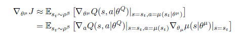

- DDPG is an actor-critic, model free, and off-policy algorithm.
- Only possible in continuous action space.
- Based on a deterministic policy gradient.

#### 2-1. Noise process

The main task in continuous action spaces is exploration. Therefore, in DDPG, the action is noisy for continuous exploration.

#### 2-2 Soft target update

It is not stable implemening Q-learning directly on neural networks. Since the Q-network being updated is also used to calculate the target value, the update tends to diverge. Therefore, the solution of this paper is 'use soft target update for the stability of learning'.

Q 'is Critic, μ' is Actor. Limit the target values to change slowly to increase the stability of learning.

#### 2-3. Experience Replay

DDPG uses a Experience Replay to reduce correlations between samples. Experience Replay(=replay buffer) is to store in replay memory the experiences that agents gain from exploring in the environment. As the agent learns, it randomly takes several samples from this memory and updates the neural network. So,it can eliminate the correlation between samples. In addition, the training is stable because the neural network is updated through several samples extracted from replay memory.

#### 2-4. Batch normalization

When using different sizes as states, neural networks have difficulty in generalization. In order to solve this problem, I added batch normalization on network.

#### 2-5. Pseudocode

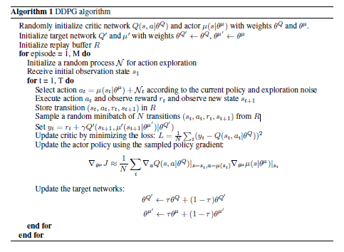

### 3. Result

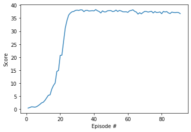

- 23rd episode, it surpassed 30 scores
- It reached 91th episodes with an average score of 30.
- As you can see from the graph, it keeps 36-38 scores from 25 episodes to the end.
- Under the same conditions, using Batch Normalization shortened 3-8 episodes.

### 4. Improvements

I realized that the number of nodes and depth of the neural network had a big impact on the results, but the optimal number of nodes and depth of layers were unknown. I would like to research the automation method to find the optimal neural network. Plus, I want to study how to apply algorithms like DDPG to finance such as stock trading.

Thank you.